# Bioinformatics Analysis and Visualisation of Medical Genomics Data - H7F5633 - Assignment 1

#### Using ggplot()

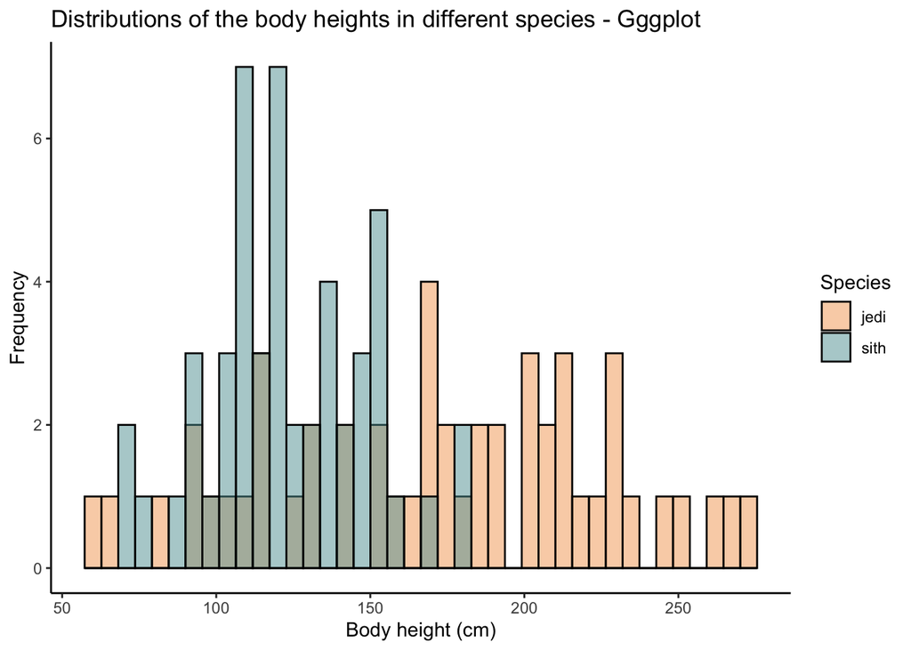

```r
body_heights <- magic_guys$length
species <-  unique(magic_guys$species)

# creates a histogram with the two groups in different colors, with 40 breaks (bins)
# The colors of the groups and the titles (plot, axis and legend) are customized
# The bars are semi-transparents to see a potential overlap of the two histograms
histo_gg <- ggplot(magic_guys, aes(x = body_heights, fill = as.factor(species))) +
# the argument "identity" og geom_histogram() allows to have two separate histograms instead of having only one and the argument apha allows to change the transparency so that we can see the overlap (instead of one histogram masking the other)
geom_histogram(color = "black", bins = 40, alpha = 0.5, position = "identity") +
scale_fill_manual(values = c("sandybrown", "cadetblue"), name = "Species") +
theme_classic() +
labs(title = "Distributions of the body heights in different species - Gggplot", x = "Body height (cm)", y = "Frequency")

print(histo_gg)
```

### b. Boxplots

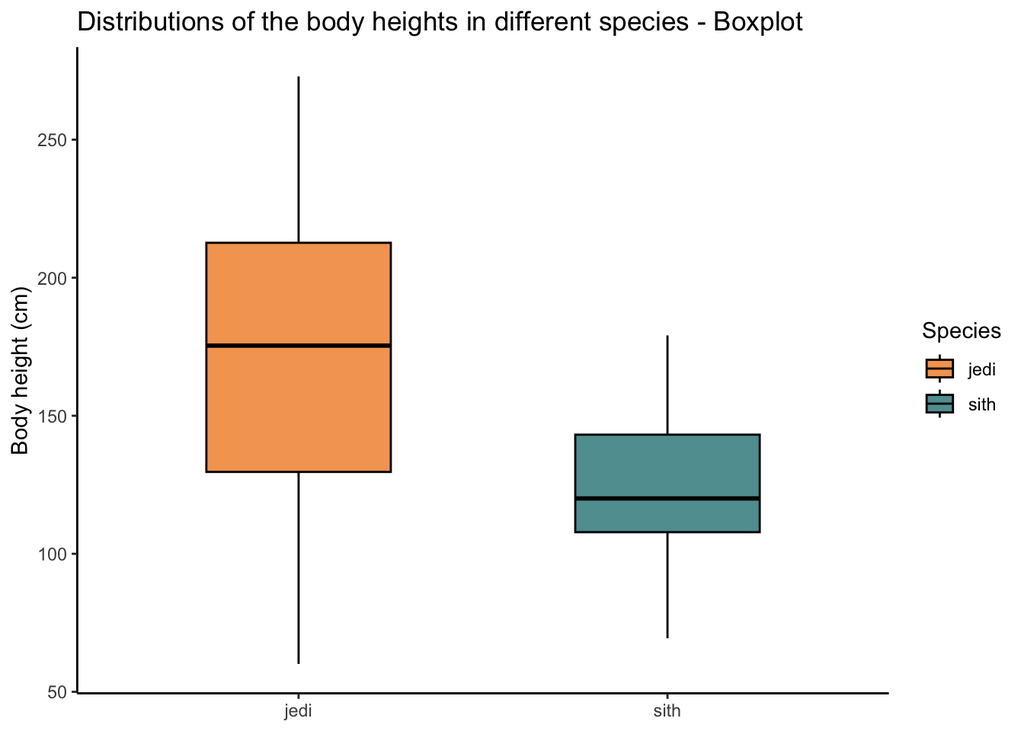

```r
body_heights <- magic_guys$length
species <-  unique(magic_guys$species)

box_gg <- ggplot(magic_guys, aes(x = species, y = body_heights, fill = as.factor(species))) +
  geom_boxplot(width = 0.5, color = "black") +
  scale_fill_manual(values = c("sandybrown", "cadetblue"), name = "Species") +
  theme_classic() +
  labs(title = "Distributions of the body heights in different species - Boxplot", x = NULL, y = "Body height (cm)")

print(box_gg)
```

### c. Saving plots in various formats

```r
# choosing the working directory where the files will be saved
setwd("~/Desktop/SciLifeLab_Riken/")

# opens a png file and names it
png("boxplot.png")

# print the boxplot
print(box_gg)

# close the file
dev.off()
```

```r
# Same with pdf file
pdf("boxplot.pdf")
print(box_gg)
dev.off()
```

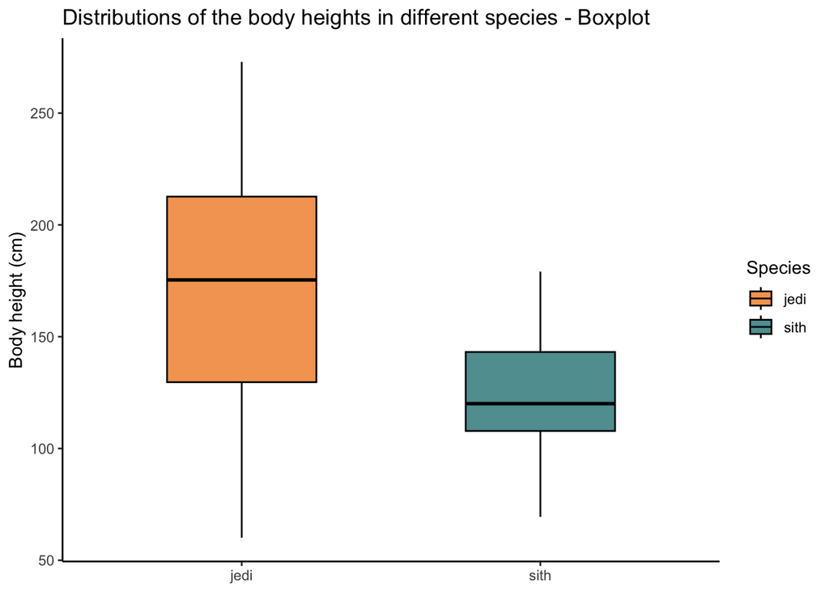

```r
# Same with svg file
svg("boxplot.svg")
print(box_gg)
```

```r
dev.off()
```

```r
# Other attempts to save a svg file... still doesn't work
ggsave("boxplot.svg", plot = box_gg)
# Other attempts to save a svg file... Now loading the "svglite" package (after having installed it on the console) o) as it seems it was missing
library(svglite)
ggsave("boxplot.svg", plot = box_gg)
```

Notes: - I got multiple errors before I managed to save as “.svg” file. I solved this by installing and loading the package “svglite” - I get a problem when “knitting” if I write “install.packages(”svglite”) in the R chunk, so I have to write it only in the console.

## 2. Work with “microarray_data.tab”

### a.

```r
# Reads the microarray file (specify the separator as "\ t")
microarray <- read.table("~/Desktop/SciLifeLab_Riken/microarray_data.tab", header=TRUE, sep="\t")
# Calculates number of columns
cols <- ncol(microarray)
# Calculates number of rows
rows <- nrow(microarray)
print(paste("The", "matrix", "has", cols, "columns", "and", rows, "rows"))
```

```
## [1] "The matrix has 1000 columns and 553 rows"
```

### b.

```r
# Uses is.na() function to identify the missing values and uses colSums() to calculate this for each column
na_count <- colSums(is.na(microarray))
# print the 10 first values of "na_count"
print(head(na_count, 10))
```

```
##  g1  g2  g3  g4  g5  g6  g7  g8  g9 g10
## 130 104  74  93  81  30  31  26  12  56
```

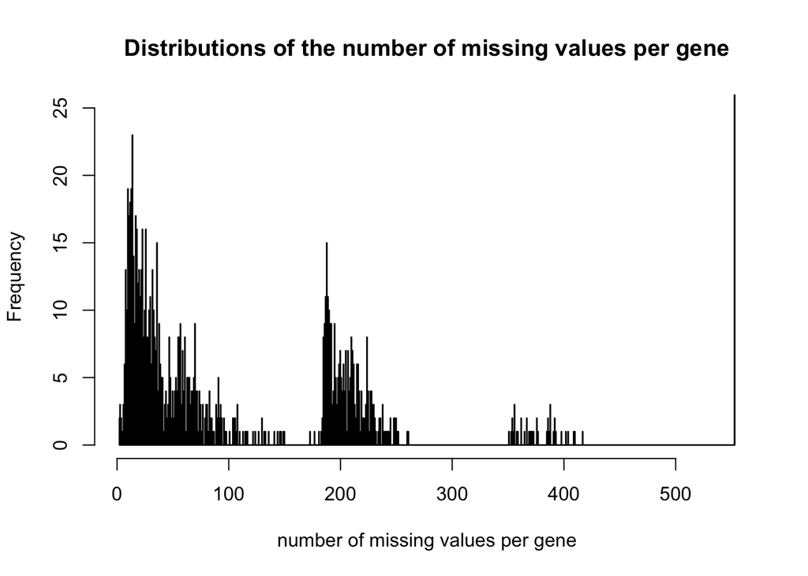

```r
hist(na_count,
     border = "black",
     breaks = cols,
     xlim = range(na_count),
     ylim = c(0, 25),
     xlab = "number of missing values per gene",
     ylab = "Frequency",
     main = "Distributions of the number of missing values per gene"
     )
```

### c.

```r
# creates a new function to calculate the percentage of

na_count_df <- as.data.frame(na_count)

calcul_percent <- function(x) {
        return(x/rows*100)
    }

# Apply this new function of all elemnts of the vector na_count
na_count_df$percent <- sapply(na_count_df$na_count, function(x) calcul_percent(x))

na_count_df$gene_name <- row.names(na_count_df)

# creates a new function to detect which genes have more than 50% or 20% or 10% missing values
missing_val <- function(w, x, y, z) {
  if (x > y) {
    z <- c(z, w)
  }
  return(z)
}

# Creates a vector with the different percentages of missing values to be tested (10, 20 and 50%)
cut_off <- c(10, 20, 50)
genes <- na_count_df$gene_name

# Creates a loop to find the genes with missing values for the cut-offs contained in the vector "cut_off"
for (y in cut_off) {
  # Creates an empty vector, which will later be filled with the names of genes
  z <- c()
  # Creates a loop so that the empty vector is filled for the genes with a % value greater than y
  for (w in genes) {
    x <- na_count_df$percent[na_count_df$gene_name == w]
    z <- missing_val(w, x, y, z)
  }
  # If the vector containing the genes with a % value greater than y are longer than 0 (meaning there is at least 1 gene that is contained in the vector), it will print a sentence along with the names of those genes
  if (length(z) > 0) {
    print(paste("Genes with greater than", y, "% missing values:", paste(z, collapse=", ")))
  } else {
    print(paste("No genes with greater than", y, "% missing values"))
  }
}
```

```
## [1] "Genes with greater than 10 % missing values: g1, g2, g3, g4, g5, g10, g11, g12, g14, g15, g16, g18, g21, g22, g23, g24, g25, g26, g28, g29, g35, g36, g37, g38, g39, g40, g41, g42, g44, g45, g46, g47, g48, g49, g50, g51, g52, g53, g54, g55, g56, g57, g58, g59, g60, g61, g62, g63, g64, g65, g6…
## [1] "Genes with greater than 20 % missing values: g1, g14, g18, g21, g22, g24, g25, g26, g29, g39, g40, g41, g48, g51, g52, g53, g54, g55, g56, g57, g58, g59, g60, g61, g62, g63, g64, g65, g66, g67, g68, g69, g70, g71, g72, g73, g74, g75, g76, g77, g78, g79, g80, g81, g82, g83, g84, g85, g86, g87…
## [1] "Genes with greater than 50 % missing values: g18, g48, g55, g58, g60, g66, g73, g79, g83, g91, g93, g94, g99, g105, g109, g132, g135, g137, g138, g172, g260, g290, g301, g329, g352, g355, g362, g363, g368, g383, g388, g389, g390, g391, g406, g417, g431, g432, g440, g461, g462, g498, g519, g5…
```

### d.

```r
# Calculate the mean of each columns of "microarray", while ignoring NAs
mean_result <- colMeans(microarray, na.rm = TRUE)

# create a vector of gene names by taking the column names of "micrpoarray"
microarray_genes <- colnames(microarray)

#print "microarray" before changing the NA values
print(head(microarray[, 1:10], 10))
```

```
##        g1     g2     g3     g4     g5     g6     g7     g8     g9    g10
## 1   1.802     NA -0.182  1.312  3.497  0.439  0.777  0.379  0.336  0.877
## 2      NA     NA  7.693     NA  0.193 -1.383 -1.309 -0.424 -0.270 -0.519
## 3   1.079     NA  1.556  1.652     NA  0.460  0.715  0.375 -0.138 -0.261
## 4   3.607     NA  1.914     NA  1.400  1.109  2.143  1.571 -0.271 -0.309
## 5  -1.700     NA  0.943     NA -0.170     NA -0.041     NA -0.069  1.533
## 6      NA     NA  0.043     NA  0.729 -0.089  0.209 -0.308  0.474 -0.655
## 7      NA     NA     NA     NA     NA     NA     NA  2.026 -0.567 -3.088
## 8      NA     NA     NA     NA     NA -1.297 -0.506 -0.228  0.595 -0.063
## 9      NA  1.831     NA  1.596     NA  2.656  4.831  0.677 -1.678  0.016
## 10     NA -2.340     NA -1.833 -2.095 -2.083 -2.977 -1.140 -1.375 -0.218
```

```r
# replace NA with the average expression value for the particular gene using a loop (for each gene)
for (gene in microarray_genes) {
  microarray[is.na(microarray[,gene]), gene] <- mean_result[gene]
}

#print "microarray" after this change
print(head(microarray[, 1:10], 10))
```

```
##             g1         g2         g3          g4          g5         g6      g7
## 1   1.80200000  0.1656927 -0.1820000  1.31200000  3.49700000  0.4390000  0.7770
## 2   0.02547518  0.1656927  7.6930000 -0.06731957  0.19300000 -1.3830000 -1.3090
## 3   1.07900000  0.1656927  1.5560000  1.65200000 -0.01812288  0.4600000  0.7150
## 4   3.60700000  0.1656927  1.9140000 -0.06731957  1.40000000  1.1090000  2.1430
## 5  -1.70000000  0.1656927  0.9430000 -0.06731957 -0.17000000 -0.1571338 -0.0410
## 6   0.02547518  0.1656927  0.0430000 -0.06731957  0.72900000 -0.0890000  0.2090
## 7   0.02547518  0.1656927 -0.1230605 -0.06731957 -0.01812288 -0.1571338 -0.2625
## 8   0.02547518  0.1656927 -0.1230605 -0.06731957 -0.01812288 -1.2970000 -0.5060
## 9   0.02547518  1.8310000 -0.1230605  1.59600000 -0.01812288  2.6560000  4.8310
## 10  0.02547518 -2.3400000 -0.1230605 -1.83300000 -2.09500000 -2.0830000 -2.9770
##            g8     g9    g10
## 1   0.3790000  0.336  0.877
## 2  -0.4240000 -0.270 -0.519
## 3   0.3750000 -0.138 -0.261
## 4   1.5710000 -0.271 -0.309
## 5  -0.1771063 -0.069  1.533
## 6  -0.3080000  0.474 -0.655
## 7   2.0260000 -0.567 -3.088
## 8  -0.2280000  0.595 -0.063
## 9   0.6770000 -1.678  0.016
## 10 -1.1400000 -1.375 -0.218
```

## 3. Visualize the data in CO2 dataset in a way that gives you a deeper understanding of the data

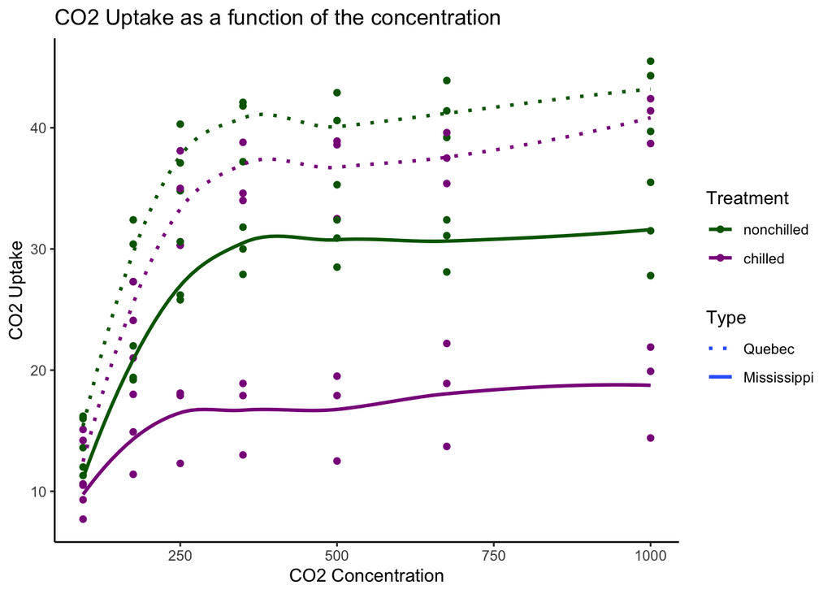

```r
# Plot the CO2 uptake as a function of the concentration, with different colors for "Treatment" and different line type for the "Type"
ggplot(CO2, aes(x = conc, y = uptake, color = Treatment, linetype = Type)) +
  geom_point() +
  # add a trend line
  geom_smooth(method = "loess", se = FALSE) +
  labs(x = "CO2 Concentration",
       y = "CO2 Uptake",
       title = "CO2 Uptake as a function of the concentration") +
  # Different colors depending on Treatment
  scale_color_manual(values = c("darkgreen", "darkmagenta")) +
  # Different line types depending on Type
  scale_linetype_manual(values = c("dotted", "solid")) +
  theme_classic()
```

What I see: - CO2 uptake is higher in non-chilled compared to chilled treatment - CO2 uptake is higher in Quebec compared to Mississippi - CO2 uptake seems to reach a plateau after a certain concentration

# Task 7

## 1. Install Tidybiology package, using: devtools::install_github(“hirscheylab/tidybiology”)

```r
# loading the "tidybiology" package (after installing it)
library(tidybiology)
# printing the "chromosome" dataset
print(head(chromosome, 5))
```

```
## # A tibble: 5 × 14
##   id    length_mm basepairs variations protein_codinggenes pseudo_genes
##   <fct>     <dbl>     <dbl>      <dbl>               <int>        <int>
## 1 1            85 248956422   12151146                2058         1220
## 2 2            83 242193529   12945965                1309         1023
## 3 3            67 198295559   10638715                1078          763
## 4 4            65 190214555   10165685                 752          727
## 5 5            62 181538259    9519995                 876          721
## # ℹ 8 more variables: totallongnc_rna <int>, totalsmallnc_rna <int>,
## #   mi_rna <int>, r_rna <int>, sn_rna <int>, sno_rna <int>, miscnc_rna <int>,
## #   centromereposition_mbp <dbl>
```

```r
# printing the "proteins" dataset
print(head(proteins, 5))
```

```
## # A tibble: 5 × 8
##   uniprot_id gene_name gene_name_alt   protein_name    protein_name_alt sequence
##   <chr>      <chr>     <chr>           <chr>           <chr>            <chr>
## 1 P04217     A1BG      <NA>            "Alpha-1B-glyc… Alpha-1-B glyco… MSMLVVF…
## 2 Q9NQ94     A1CF      ACF ASP         "APOBEC1 compl… APOBEC1-stimula… MESNHKS…
## 3 P01023     A2M       CPAMD5 FWP007   "Alpha-2-macro… Alpha-2-M) (C3 … MGKNKLL…
## 4 A8K2U0     A2ML1     CPAMD9          "Alpha-2-macro… C3 and PZP-like… MWAQLLL…
## 5 U3KPV4     A3GALT2   A3GALT2P IGBS3S "Alpha-1,3-gal… EC 2.4.1.87) (I… MALKEGL…
## # ℹ 2 more variables: length <dbl>, mass <dbl>
```

### a.

```r
# Creates a matrix to be filled with summary data
data_summary <- matrix(NA, nrow = 3, ncol = 3)

# Set the names for the columns and rows of this matrix
colnames(data_summary) <- c("variations", "protein_codinggenes", "mi_rna")
rownames(data_summary) <- c("mean", "median", "maximum")

# Print the empty matrix
print(data_summary)
```

```
##         variations protein_codinggenes mi_rna
## mean            NA                  NA     NA
## median          NA                  NA     NA
## maximum         NA                  NA     NA
```

```r
# Create a loop so that the statistics are calculated for the three variables of interest
for (v in colnames(data_summary)) {
  # Use the tidyverse to select the column of the variable of interest from the chromosome dataset
  current_data <- chromosome %>%
    select(v)  %>%
    # convert this data into a vector
    unlist()

# Fill the matrix with the summary data
data_summary["mean", v] <- mean(current_data)
data_summary["median", v] <- median(current_data)
data_summary["maximum", v] <- max(current_data)
}
print(data_summary)
```

```
##         variations protein_codinggenes    mi_rna
## mean       6484572            849.9583  73.16667
## median     6172346            836.0000  75.00000
## maximum   12945965           2058.0000 134.00000
```

### b.

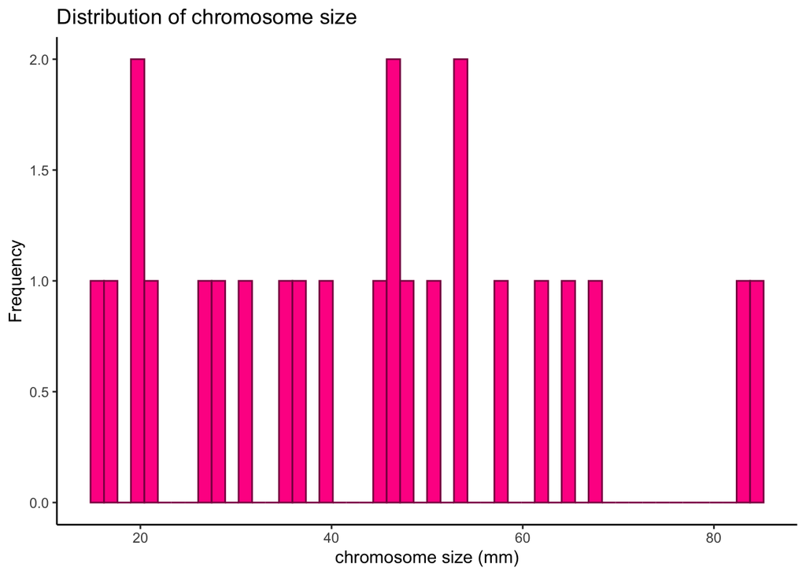

```r
# Creates an histogram using ggplot
distrib <- ggplot(chromosome, aes(x = length_mm)) +
geom_histogram(color = "deeppink4", fill = "deeppink", bins =50) +
theme_classic() +
labs(title = "Distribution of chromosome size", x = "chromosome size (mm)", y = "Frequency")

print(distrib)
```

### c.

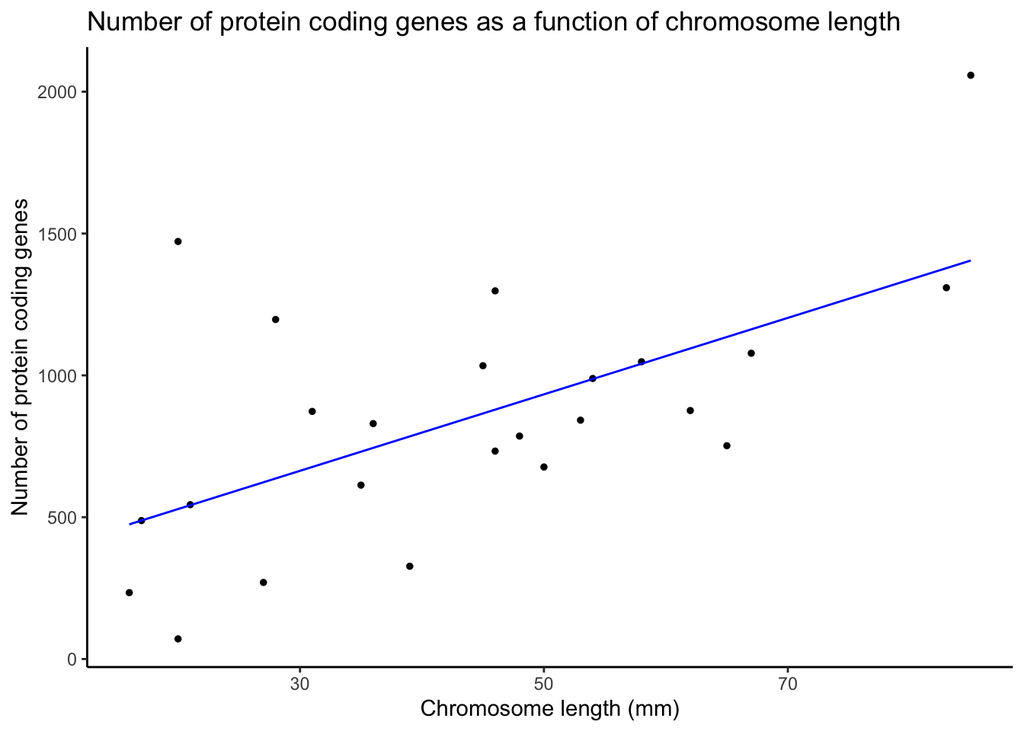

```r
# Plot to visualize a potential correlation between the number of protein coding genes and the length of the chromosome
blue <- ggplot(chromosome, aes(x = length_mm, y = protein_codinggenes)) +
  geom_point(size = 1, color = "black") +
  labs(x = "Chromosome length (mm)",
       y = "Number of protein coding genes",
       title = "Number of protein coding genes as a function of chromosome length") +
  theme_classic() +
  # Add a line to visualize a linear regression
  geom_smooth(method = "lm", se = FALSE, color = "blue", size = 0.5)
print(blue)
```

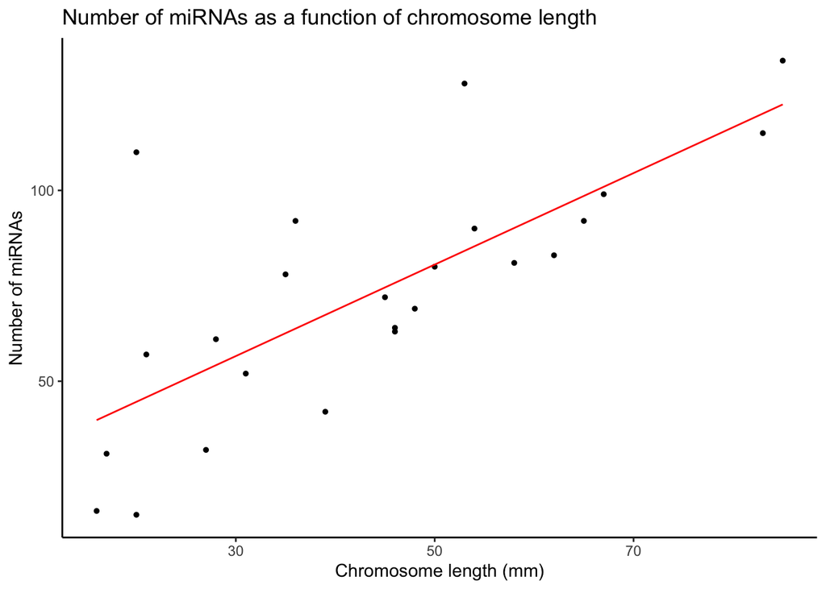

```r
# Plot to visualize a potential correlation between the number of miRNAs and the length of the chromosome
red <- ggplot(chromosome, aes(x = length_mm, y = mi_rna)) +
  geom_point(size = 1, color = "black") +
  labs(x = "Chromosome length (mm)",
       y = "Number of miRNAs",
       title = "Number of miRNAs as a function of chromosome length") +
  theme_classic() +
  # Add a line to visualize a linear regression
  geom_smooth(method = "lm", se = FALSE, color = "red", size = 0.5)

print(red)
```

Outcome: Both the number of protein coding genes and the number of miRNAs correlate with the chromosome length

### d.

```r
summarized_data <- matrix(NA, nrow = 3, ncol = 2)

# Set the names for the columns and rows of this matrix
colnames(summarized_data) <- c("length", "mass")
rownames(summarized_data) <- c("mean", "median", "maximum")

# Create a loop so that the statistics are calculated for the three variables of interest
for (v in colnames(summarized_data)) {
  # Use the tidyverse to select the column of the variable of interest from the chromosome dataset
  current_data <- proteins %>%
    select(v)  %>%
    # convert this data into a vector
    unlist()

# Fill the matrix with the summarized data
summarized_data["mean", v] <- mean(current_data)
summarized_data["median", v] <- median(current_data)
summarized_data["maximum", v] <- max(current_data)
}

print(summarized_data)
```

```
##             length       mass
## mean      557.1603   62061.38
## median    414.0000   46140.50
## maximum 34350.0000 3816030.00
```

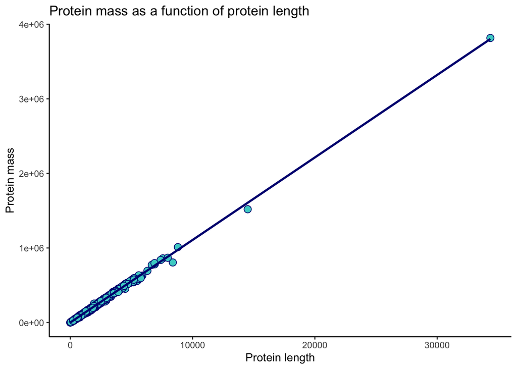

```r
#
length_vs_mass <- ggplot(proteins, aes(x = length, y = mass)) +
  geom_point(size = 3, color = "navyblue", fill = "mediumturquoise", shape = 21) +
  labs(x = "Protein length",
       y = "Protein mass",
       title = "Protein mass as a function of protein length") +
  theme_classic() +
  geom_smooth(method = "lm", se = FALSE, color = "navyblue", size = 1)

print(length_vs_mass)
```